# 楊子萱_110700049_hw07

## 4. Support Vector Machines Using Soft Margin Linear Classifier

### Training & Evaluation

```r
soft_margin_svm_model <- svm(Quality.of.Sleep ~ Sleep.Duration + Age + Gender + Stress.Level + Sleep.Disorder + Heart.Rate,
                             data = train, type = "C-classification", kernel = "linear", cost = 1)

predicted_classes_soft_margin_svm <- predict(soft_margin_svm_model, newdata = valid)

confusion_matrix_soft_margin_svm <- table(Actual = valid$Quality.of.Sleep, Predicted = predicted_classes_soft_margin_svm)

accuracy_soft_margin_svm <- sum(diag(confusion_matrix_soft_margin_svm)) / sum(confusion_matrix_soft_margin_svm)
precision_soft_margin_svm <- diag(confusion_matrix_soft_margin_svm) / rowSums(confusion_matrix_soft_margin_svm)
recall_soft_margin_svm <- diag(confusion_matrix_soft_margin_svm) / colSums(confusion_matrix_soft_margin_svm)
f1_score_soft_margin_svm <- 2 * (precision_soft_margin_svm * recall_soft_margin_svm) /
                            (precision_soft_margin_svm + recall_soft_margin_svm)
overall_precision_soft_margin_svm <- mean(precision_soft_margin_svm, na.rm = TRUE)
overall_recall_soft_margin_svm <- mean(recall_soft_margin_svm, na.rm = TRUE)
overall_f1_score_soft_margin_svm <- mean(f1_score_soft_margin_svm, na.rm = TRUE)
kappa_test <- kappam.fleiss(confusion_matrix_soft_margin_svm)$value

intersection <- sum(diag(confusion_matrix_soft_margin_svm))
union <- sum(confusion_matrix_soft_margin_svm) + sum(confusion_matrix_soft_margin_svm) - sum(diag(confusion_matrix_soft_margin_svm))
jaccard_index <- intersection / union

print(confusion_matrix_soft_margin_svm)
```

```
##       Predicted
## Actual  1  2  3  4  5  6
##      1  1  0  0  0  0  0
##      2  0  1  0  0  0  0
##      3  0  0 14  0  0  0
##      4  0  0  0 23  0  0
##      5  0  0  0  2 20  0
##      6  0  0  0  0  0 13
```

```r
cat("Accuracy (Soft-Margin SVM):", accuracy_soft_margin_svm, "\n")
```

```
## Accuracy (Soft-Margin SVM): 0.972973
```

```r
cat("Overall Precision (Soft-Margin SVM):", overall_precision_soft_margin_svm, "\n")
```

```
## Overall Precision (Soft-Margin SVM): 0.9848485
```

```r
cat("Overall Recall (Soft-Margin SVM):", overall_recall_soft_margin_svm, "\n")
```

```
## Overall Recall (Soft-Margin SVM): 0.9866667
```

```r
cat("Overall F1-Score (Soft-Margin SVM):", overall_f1_score_soft_margin_svm, "\n")
```

```
## Overall F1-Score (Soft-Margin SVM): 0.985119
```

```r
cat("Cohen's Kappa (Soft-Margin SVM):", kappa_test, "\n")
```

```
## Cohen's Kappa (Soft-Margin SVM): -0.09775785
```

```r
cat("Jaccard Index (Soft-Margin SVM):", jaccard_index, "\n")
```

```
## Jaccard Index (Soft-Margin SVM): 0.9473684
```

I set the cost to **1** to make it a soft margin linear classifier.

Out of the 74 valid data points, we can see from the confusion matrix that there’re only **2** observations that have predictions in the incorrect class. By looking at the performance metrics, this model is **performing pretty good**. The overall accuracy, precision, recall, F1-Score, and Jaccard index are all **quite high** . Nevertheless, the **negative** value of Cohen’s Kappa suggests that the **agreement is worse** than what would be expected by chance. This infers that perhaps the **reliability** of this SVM model’s predictions needs to be taken into account.

### Test Set Evaluation

```r
predicted_classes_svm_test <- predict(soft_margin_svm_model, newdata = test)

confusion_matrix_svm_test <- table(Actual = test$Quality.of.Sleep, Predicted = predicted_classes_svm_test)

accuracy_svm_test <- sum(diag(confusion_matrix_svm_test)) / sum(confusion_matrix_svm_test)
precision_svm_test <- diag(confusion_matrix_svm_test) / rowSums(confusion_matrix_svm_test)
recall_svm_test <- diag(confusion_matrix_svm_test) / colSums(confusion_matrix_svm_test)
f1_score_svm_test <- 2 * (precision_svm_test * recall_svm_test) / (precision_svm_test + recall_svm_test)
overall_precision_svm_test <- mean(precision_svm_test, na.rm = TRUE)
overall_recall_svm_test <- mean(recall_svm_test, na.rm = TRUE)
overall_f1_score_svm_test <- mean(f1_score_svm_test, na.rm = TRUE)
kappa_test <- kappam.fleiss(confusion_matrix_svm_test)$value

intersection <- sum(diag(confusion_matrix_svm_test))
union <- sum(confusion_matrix_svm_test) + sum(confusion_matrix_svm_test) - sum(diag(confusion_matrix_svm_test))
jaccard_index <- intersection / union

print(confusion_matrix_svm_test)
```

```
##       Predicted
## Actual  1  2  3  4  5  6
##      1  1  0  0  0  0  0
##      2  0  1  1  0  0  0
##      3  0  1 25  0  0  0
##      4  0  0  1 14  0  0
##      5  0  0  0  3 18  0
##      6  0  0  0  0  0 11
```

```r
cat("Accuracy (Soft-Margin SVM - Test Set):", accuracy_svm_test, "\n")
```

```
## Accuracy (Soft-Margin SVM - Test Set): 0.9210526
```

```r
cat("Overall Precision (Soft-Margin SVM - Test Set):", overall_precision_svm_test, "\n")
```

```
## Overall Precision (Soft-Margin SVM - Test Set): 0.8753358
```

```r
cat("Overall Recall (Soft-Margin SVM - Test Set):", overall_recall_svm_test, "\n")
```

```
## Overall Recall (Soft-Margin SVM - Test Set): 0.8749092
```

```r
cat("Overall F1-Score (Soft-Margin SVM - Test Set):", overall_f1_score_svm_test, "\n")
```

```
## Overall F1-Score (Soft-Margin SVM - Test Set): 0.8735789
```

```r
cat("Cohen's Kappa (Soft-Margin SVM - Test Set):", kappa_test, "\n")
```

```
## Cohen's Kappa (Soft-Margin SVM - Test Set): -0.09830508
```

```r
cat("Jaccard Index (Soft-Margin SVM - Test Set):", jaccard_index, "\n")
```

```
## Jaccard Index (Soft-Margin SVM - Test Set): 0.8536585
```

Out of the 76 test data points, we can see from the confusion matrix that there’re **6** observations that have predictions in the incorrect class. On top of that, by looking at the performance metrics, this model is **stll performing great**, but the figures are **a bit lower** than the metrics for validation set. Additionally, the value of Cohen’s Kappa is still **negative**, so the **reliability** of the model’s predictions needs to be taken into account. There may be some little **overfitting** issues.

## 5. Nonlinear SVM with a Radial Basis Function (RBF) Kernel

### Training & Evaluation

```r
predictors <- c("Sleep.Duration", "Age", "Gender", "Stress.Level", "Sleep.Disorder", "Heart.Rate")
response_var <- "Quality.of.Sleep"

nonlinear_svm_model <- svm(as.factor(Quality.of.Sleep) ~ Sleep.Duration + Age + Gender + Stress.Level + Sleep.Disorder + Heart.Rate,
                            data = train,
                            type = "C-classification",
                            kernel = "radial",
                            decision.values = TRUE,
                            cost = 0.1,
                            gamma = 0.1)

predicted_classes_nonlinear_svm <- predict(nonlinear_svm_model, newdata = valid)

confusion_matrix_nonlinear_svm <- table(Actual = valid$Quality.of.Sleep, Predicted = predicted_classes_nonlinear_svm)

accuracy_nonlinear_svm <- sum(diag(confusion_matrix_nonlinear_svm)) / sum(confusion_matrix_nonlinear_svm)
precision_nonlinear_svm <- diag(confusion_matrix_nonlinear_svm) / rowSums(confusion_matrix_nonlinear_svm)
recall_nonlinear_svm <- diag(confusion_matrix_nonlinear_svm) / colSums(confusion_matrix_nonlinear_svm)
f1_score_nonlinear_svm <- 2 * (precision_nonlinear_svm * recall_nonlinear_svm) / (precision_nonlinear_svm + recall_nonlinear_svm)
overall_precision_nonlinear_svm <- mean(precision_nonlinear_svm, na.rm = TRUE)
overall_recall_nonlinear_svm <- mean(recall_nonlinear_svm, na.rm = TRUE)
overall_f1_score_nonlinear_svm <- mean(f1_score_nonlinear_svm, na.rm = TRUE)
kappa <- kappam.fleiss(confusion_matrix_nonlinear_svm)$value

intersection <- sum(diag(confusion_matrix_nonlinear_svm))
union <- sum(confusion_matrix_nonlinear_svm) + sum(confusion_matrix_nonlinear_svm) - sum(diag(confusion_matrix_nonlinear_svm))
jaccard_index <- intersection / union

print(confusion_matrix_nonlinear_svm)
```

```
##       Predicted
## Actual  1  2  3  4  5  6
##      1  0  0  1  0  0  0
##      2  0  0  1  0  0  0
##      3  0  0 14  0  0  0
##      4  0  0  3 11  9  0
##      5  0  0  0  0 22  0
##      6  0  0  0  0  0 13
```

```r
cat("Accuracy (RBF SVM):", accuracy_nonlinear_svm, "\n")
```

```
## Accuracy (RBF SVM): 0.8108108
```

```r
cat("Overall Precision (RBF SVM):", overall_precision_nonlinear_svm, "\n")
```

```
## Overall Precision (RBF SVM): 0.5797101
```

```r
cat("Overall Recall (RBF SVM):", overall_recall_nonlinear_svm, "\n")
```

```
## Overall Recall (RBF SVM): 0.8616299
```

```r
cat("Overall F1-Score (RBF SVM):", overall_f1_score_nonlinear_svm, "\n")
```

```
## Overall F1-Score (RBF SVM): 0.8314331
```

```r
cat("Cohen's Kappa (RBF SVM):", kappa, "\n")
```

```
## Cohen's Kappa (RBF SVM): -0.06135458
```

```r
cat("Jaccard Index (RBF SVM):", jaccard_index, "\n")
```

```
## Jaccard Index (RBF SVM): 0.6818182
```

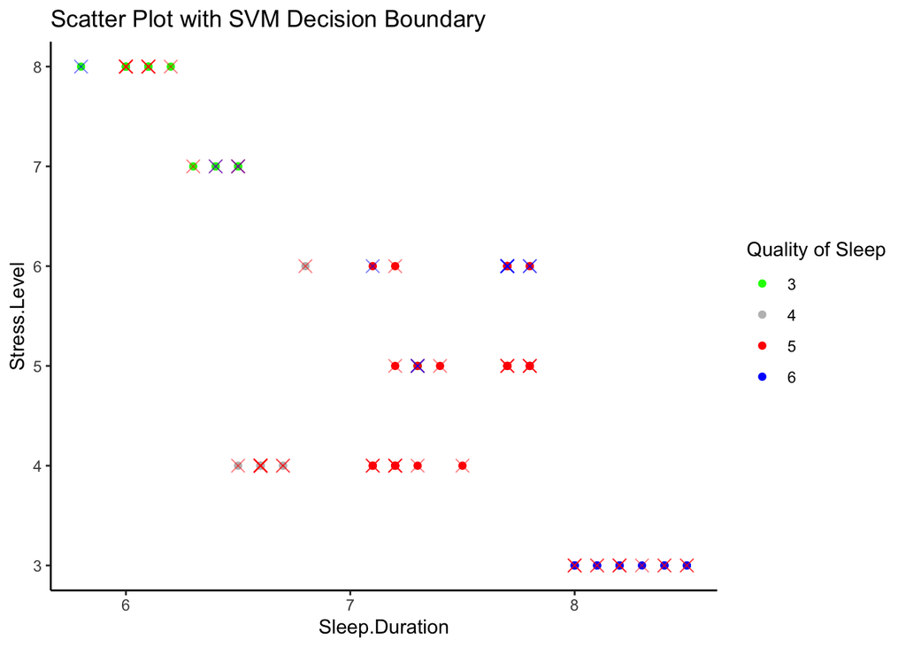

```r
library(ggplot2)

feature1 <- valid$Sleep.Duration
feature2 <- valid$Stress.Level

plot_data <- data.frame(Sleep.Duration = feature1, Stress.Level = feature2, Quality.of.Sleep = as.factor(predicted_classes_nonlinear_svm))

unique_values <- levels(plot_data$Quality.of.Sleep)

color_palette <- c("green", "gray", "red", "blue")

ggplot(plot_data, aes(x = Sleep.Duration, y = Stress.Level, color = Quality.of.Sleep)) +
  geom_point() +
  scale_color_manual(values = color_palette[1:length(unique_values)]) +
  theme_classic() +
  ggtitle("Scatter Plot with SVM Decision Boundary") +
  labs(color = "Quality of Sleep") +
  geom_point(data = plot_data[which(predicted_classes_nonlinear_svm == valid$Quality.of.Sleep), ],
             color = "red", size = 3, shape = 4, alpha = 0.5) +
  geom_point(data = plot_data[which(predicted_classes_nonlinear_svm != valid$Quality.of.Sleep), ],
             color = "blue", size = 3, shape = 4, alpha = 0.5) +
  geom_contour(data = plot_data, aes(z = as.numeric(Quality.of.Sleep)), color = "black", bins = 1)
```

The scatter plot shows that better quality of sleep can be achieved with **more sleep duration** (more than 8), and **less stress level** (less or equal to 3).

### Test Set Evaluation

```r
predicted_classes_svm_test <- predict(nonlinear_svm_model, newdata = test)

confusion_matrix_svm_test <- table(Actual = test$Quality.of.Sleep, Predicted = predicted_classes_svm_test)

accuracy_svm_test <- sum(diag(confusion_matrix_svm_test)) / sum(confusion_matrix_svm_test)
precision_svm_test <- diag(confusion_matrix_svm_test) / rowSums(confusion_matrix_svm_test)
recall_svm_test <- diag(confusion_matrix_svm_test) / colSums(confusion_matrix_svm_test)
f1_score_svm_test <- 2 * (precision_svm_test * recall_svm_test) / (precision_svm_test + recall_svm_test)
overall_precision_svm_test <- mean(precision_svm_test, na.rm = TRUE)
overall_recall_svm_test <- mean(recall_svm_test, na.rm = TRUE)
overall_f1_score_svm_test <- mean(f1_score_svm_test, na.rm = TRUE)
kappa_test <- kappam.fleiss(confusion_matrix_svm_test)$value

intersection <- sum(diag(confusion_matrix_svm_test))
union <- sum(confusion_matrix_svm_test) + sum(confusion_matrix_svm_test) - sum(diag(confusion_matrix_svm_test))
jaccard_index <- intersection / union

print(confusion_matrix_svm_test)
```

```
##       Predicted
## Actual  1  2  3  4  5  6
##      1  0  0  1  0  0  0
##      2  0  0  2  0  0  0
##      3  0  0 26  0  0  0
##      4  0  0  5  4  6  0
##      5  0  0  0  0 21  0
##      6  0  0  0  0  1 10
```

```r
cat("Accuracy (RBF SVM - Test Set):", accuracy_svm_test, "\n")
```

```
## Accuracy (RBF SVM - Test Set): 0.8026316
```

```r
cat("Overall Precision (RBF SVM - Test Set):", overall_precision_svm_test, "\n")
```

```
## Overall Precision (RBF SVM - Test Set): 0.5292929
```

```r
cat("Overall Recall (RBF SVM - Test Set):", overall_recall_svm_test, "\n")
```

```
## Overall Recall (RBF SVM - Test Set): 0.8786765
```

```r
cat("Overall F1-Score (RBF SVM - Test Set):", overall_f1_score_svm_test, "\n")
```

```
## Overall F1-Score (RBF SVM - Test Set): 0.7743108
```

```r
cat("Cohen's Kappa (RBF SVM - Test Set):", kappa_test, "\n")
```

```
## Cohen's Kappa (RBF SVM - Test Set): -0.0618705
```

```r
cat("Jaccard Index (RBF SVM - Test Set):", jaccard_index, "\n")
```

```
## Jaccard Index (RBF SVM - Test Set): 0.6703297
```

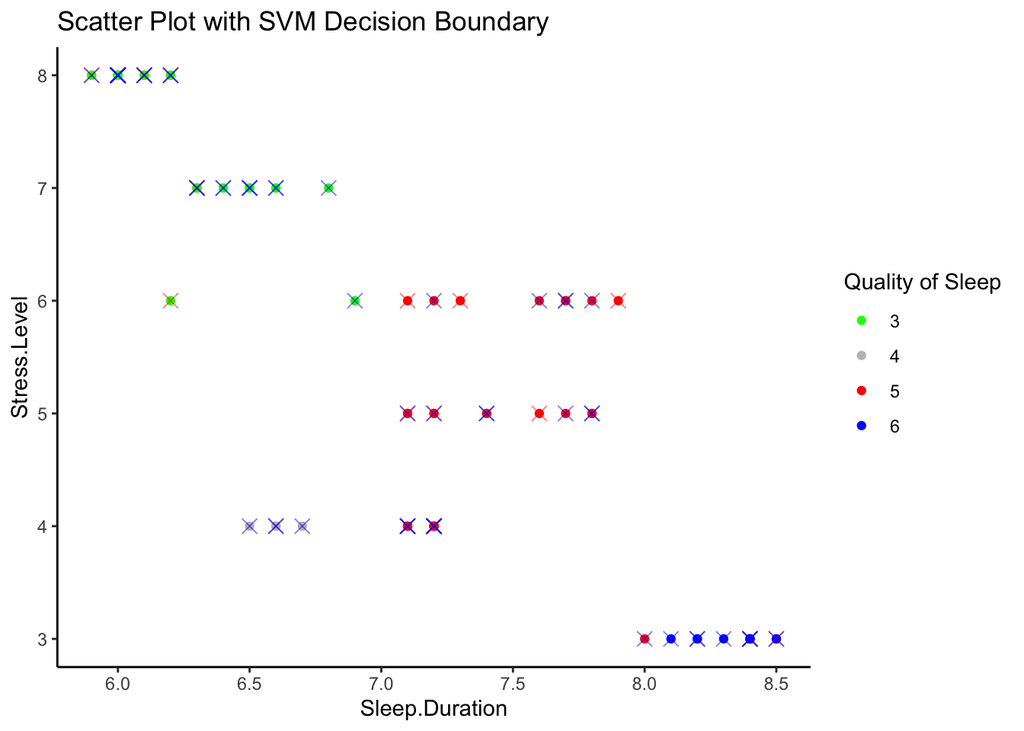

```r
feature1 <- test$Sleep.Duration
feature2 <- test$Stress.Level

plot_data <- data.frame(Sleep.Duration = feature1, Stress.Level = feature2, Quality.of.Sleep = as.factor(predicted_classes_svm_test))

unique_values <- levels(plot_data$Quality.of.Sleep)

color_palette <- c("green", "gray", "red", "blue")

ggplot(plot_data, aes(x = Sleep.Duration, y = Stress.Level, color = Quality.of.Sleep)) +
  geom_point() +
  scale_color_manual(values = color_palette[1:length(unique_values)]) +
  theme_classic() +
  ggtitle("Scatter Plot with SVM Decision Boundary") +
  labs(color = "Quality of Sleep") +
  geom_point(data = plot_data[which(predicted_classes_nonlinear_svm == test$Quality.of.Sleep), ],
             color = "red", size = 3, shape = 4, alpha = 0.5) +
  geom_point(data = plot_data[which(predicted_classes_nonlinear_svm != test$Quality.of.Sleep), ],
             color = "blue", size = 3, shape = 4, alpha = 0.5) +
  geom_contour(data = plot_data, aes(z = as.numeric(Quality.of.Sleep)), color = "black", bins = 1)
```

Although the points are a bit different, the scatter plot still ilustrates the same trend.

## 6. Nonlinear SVM with a Polynomial Kernel

### Training & Evaluation

```r
svm_regression_model <- svm(Quality.of.Sleep ~ Sleep.Duration + Age + Gender + Stress.Level + Sleep.Disorder + Heart.Rate,
                            data = train,
                            type = "eps-regression",
                            kernel = "polynomial",
                            cost = 0.1)

predicted_values_svm <- predict(svm_regression_model, newdata = valid)

mse_svm <- mean((predicted_values_svm - valid$Quality.of.Sleep)^2)
mae_svm <- mean(abs(predicted_values_svm - valid$Quality.of.Sleep))
rsquared_svm<- 1 - (sum((valid$Quality.of.Sleep - predicted_values_svm)^2) / sum((valid$Quality.of.Sleep - mean(valid$Quality.of.Sleep))^2))
mpe_svm <- mean(((valid$Quality.of.Sleep - predicted_values_svm) / valid$Quality.of.Sleep) * 100)
rmse_svm <- sqrt(mean((predicted_values_svm - valid$Quality.of.Sleep)^2))
mape_svm <- mean(abs((valid$Quality.of.Sleep - predicted_values_svm) / valid$Quality.of.Sleep) * 100)
adjusted_rsquared_svm<- summary(lm(valid$Quality.of.Sleep ~ predicted_values_svm))$adj.r.squared

cat("Mean Squared Error (MSE) for SVM with polynomial kernel:", mse_svm, "\n")
```

```
## Mean Squared Error (MSE) for SVM with polynomial kernel: 0.1017295
```

```r
cat("Mean Absolute Error (MAE)for SVM with polynomial kernel:", mae_svm, "\n")
```

```
## Mean Absolute Error (MAE)for SVM with polynomial kernel: 0.2285134
```

```r
cat("R-squared for SVM with polynomial kernel:", rsquared_svm, "\n")
```

```
## R-squared for SVM with polynomial kernel: 0.9160152
```

```r
cat("Mean Percentage Error (MPE) for SVM with polynomial kernel:", mpe_svm, "\n")
```

```
## Mean Percentage Error (MPE) for SVM with polynomial kernel: -0.3816429
```

```r
cat("Root Mean Squared Error (RMSE) for SVM with polynomial kernel:", rmse_svm, "\n")
```

```
## Root Mean Squared Error (RMSE) for SVM with polynomial kernel: 0.3189507
```

```r
cat("Mean Absolute Percentage Error (MAPE) for SVM with polynomial kernel:", mape_svm, "\n")
```

```
## Mean Absolute Percentage Error (MAPE) for SVM with polynomial kernel: 5.886415
```

```r
cat("Adjusted R-squared for SVM with polynomial kernel:", adjusted_rsquared_svm, "\n")
```

```
## Adjusted R-squared for SVM with polynomial kernel: 0.9181117
```

### Test Set Evaluation

```r
predicted_values_svm_test <- predict(svm_regression_model, newdata = test)

mse_svm_test <- mean((predicted_values_svm_test - test$Quality.of.Sleep)^2)
mae_svm_test <- mean(abs(predicted_values_svm_test - test$Quality.of.Sleep))
rsquared_svm_test <- 1 - (sum((test$Quality.of.Sleep - predicted_values_svm_test)^2) / sum((test$Quality.of.Sleep - mean(test$Quality.of.Sleep))^2))
mpe_svm_test <- mean(((test$Quality.of.Sleep - predicted_values_svm_test) / test$Quality.of.Sleep) * 100)
rmse_svm_test <- sqrt(mean((predicted_values_svm_test - test$Quality.of.Sleep)^2))
mape_svm_test <- mean(abs((test$Quality.of.Sleep - predicted_values_svm_test) / test$Quality.of.Sleep) * 100)
adjusted_rsquared_svm_test <- summary(lm(test$Quality.of.Sleep ~ predicted_values_svm_test))$adj.r.squared

cat("MSE for SVM with polynomial kernel test set:", mse_svm_test, "\n")
```

```
## MSE for SVM with polynomial kernel test set: 0.146786
```

```r
cat("MAE for SVM with polynomial kernel test set:", mae_svm_test, "\n")
```

```
## MAE for SVM with polynomial kernel test set: 0.2506532
```

```r
cat("R-squared for SVM with polynomial kernel test set:", rsquared_svm_test, "\n")
```

```
## R-squared for SVM with polynomial kernel test set: 0.8954322
```

```r
cat("MPE for SVM with polynomial kernel test set:", mpe_svm_test, "\n")
```

```
## MPE for SVM with polynomial kernel test set: 2.774468
```

```r
cat("RMSE for SVM with polynomial kernel test set:", rmse_svm_test, "\n")
```

```
## RMSE for SVM with polynomial kernel test set: 0.3831266
```

```r
cat("MAPE for SVM with polynomial kernel test set:", mape_svm_test, "\n")
```

```
## MAPE for SVM with polynomial kernel test set: 8.344063
```

```r
cat("Adjusted R-squared for SVM with polynomial kernel test set:", adjusted_rsquared_svm_test, "\n")
```

```
## Adjusted R-squared for SVM with polynomial kernel test set: 0.9017131
```

## 7. Nonlinear SVM with a Gaussian (RBF) Kernel

### Training & Evaluation

```r
svm_regression_model <- svm(Quality.of.Sleep ~ Sleep.Duration + Age + Gender + Stress.Level + Sleep.Disorder + Heart.Rate,
                                data = train,
                                type = "eps-regression",
                                kernel = "radial",
                                cost = 0.1)

predicted_values_svm <- predict(svm_regression_model, newdata = valid)

mse_svm <- mean((predicted_values_svm - valid$Quality.of.Sleep)^2)
mae_svm <- mean(abs(predicted_values_svm - valid$Quality.of.Sleep))
rsquared_svm <- 1 - (sum((valid$Quality.of.Sleep - predicted_values_svm)^2) / sum((valid$Quality.of.Sleep - mean(valid$Quality.of.Sleep))^2))
mpe_svm <- mean(((valid$Quality.of.Sleep - predicted_values_svm) / valid$Quality.of.Sleep) * 100)
rmse_svm <- sqrt(mean((predicted_values_svm - valid$Quality.of.Sleep)^2))
mape_svm <- mean(abs((valid$Quality.of.Sleep - predicted_values_svm) / valid$Quality.of.Sleep) * 100)
adjusted_rsquared_svm <- summary(lm(valid$Quality.of.Sleep ~ predicted_values_svm))$adj.r.squared

cat("MSE for SVM with Gaussian kernel:", mse_svm, "\n")
```

```
## MSE for SVM with Gaussian kernel: 0.1198066
```

```r
cat("MAE for SVM with Gaussian kernel:", mae_svm, "\n")
```

```
## MAE for SVM with Gaussian kernel: 0.1851826
```

```r
cat("R-squared for SVM with Gaussian kernel:", rsquared_svm, "\n")
```

```
## R-squared for SVM with Gaussian kernel: 0.9010914
```

```r
cat("MPE for SVM with Gaussian kernel:", mpe_svm, "\n")
```

```
## MPE for SVM with Gaussian kernel: -3.909254
```

```r
cat("RMSE for SVM with Gaussian kernel:", rmse_svm, "\n")
```

```
## RMSE for SVM with Gaussian kernel: 0.3461309
```

```r
cat("MAPE for SVM with Gaussian kernel:", mape_svm, "\n")
```

```
## MAPE for SVM with Gaussian kernel: 6.903088
```

```r
cat("Adjusted R-squared for SVM with Gaussian kernel:", adjusted_rsquared_svm, "\n")
```

```
## Adjusted R-squared for SVM with Gaussian kernel: 0.9152008
```

### Test Set Evaluation

```r
predicted_values_svm_test <- predict(svm_regression_model, newdata = test)

mse_svm_test <- mean((predicted_values_svm_test - test$Quality.of.Sleep)^2)
mae_svm_test <- mean(abs(predicted_values_svm_test - test$Quality.of.Sleep))
rsquared_svm_test <- 1 - (sum((test$Quality.of.Sleep - predicted_values_svm_test)^2) / sum((test$Quality.of.Sleep - mean(test$Quality.of.Sleep))^2))
mpe_svm_test <- mean(((test$Quality.of.Sleep - predicted_values_svm_test) / test$Quality.of.Sleep) * 100)
rmse_svm_test <- sqrt(mean((predicted_values_svm_test - test$Quality.of.Sleep)^2))
mape_svm_test <- mean(abs((test$Quality.of.Sleep - predicted_values_svm_test) / test$Quality.of.Sleep) * 100)
adjusted_rsquared_svm_test <- summary(lm(test$Quality.of.Sleep ~ predicted_values_svm_test))$adj.r.squared

cat("MSE for SVM with Gaussian kernel test set:", mse_svm_test, "\n")
```

```
## MSE for SVM with Gaussian kernel test set: 0.1833805
```

```r
cat("MAE for SVM with Gaussian kernel test set:", mae_svm_test, "\n")
```

```
## MAE for SVM with Gaussian kernel test set: 0.2209438
```

```r
cat("R-squared for SVM with Gaussian kernel test set:", rsquared_svm_test, "\n")
```

```
## R-squared for SVM with Gaussian kernel test set: 0.8693629
```

```r
cat("MPE for SVM with Gaussian kernel test set:", mpe_svm_test, "\n")
```

```
## MPE for SVM with Gaussian kernel test set: -4.570531
```

```r
cat("RMSE for SVM with Gaussian kernel test set:", rmse_svm_test, "\n")
```

```
## RMSE for SVM with Gaussian kernel test set: 0.4282295
```

```r
cat("MAPE for SVM with Gaussian kernel test set:", mape_svm_test, "\n")
```

```
## MAPE for SVM with Gaussian kernel test set: 8.68733
```

```r
cat("Adjusted R-squared for SVM with Gaussian kernel test set:", adjusted_rsquared_svm_test, "\n")
```

```
## Adjusted R-squared for SVM with Gaussian kernel test set: 0.8778981
```

## 8. Nonlinear SVM with a Sigmoid Kernel

### Training & Evaluation

```r
svm_regression_model <- svm(Quality.of.Sleep ~ Sleep.Duration + Age + Gender + Stress.Level + Sleep.Disorder + Heart.Rate,
                            data = train,
                            type = "eps-regression",
                            kernel = "sigmoid",
                            cost = 0.1)

predicted_values_svm <- predict(svm_regression_model, newdata = valid)

mse_svm <- mean((predicted_values_svm - valid$Quality.of.Sleep)^2)
mae_svm <- mean(abs(predicted_values_svm - valid$Quality.of.Sleep))
rsquared_svm <- 1 - (sum((valid$Quality.of.Sleep - predicted_values_svm)^2) / sum((valid$Quality.of.Sleep - mean(valid$Quality.of.Sleep))^2))
mpe_svm <- mean(((valid$Quality.of.Sleep - predicted_values_svm) / valid$Quality.of.Sleep) * 100)
rmse_svm <- sqrt(mean((predicted_values_svm - valid$Quality.of.Sleep)^2))
mape_svm <- mean(abs((valid$Quality.of.Sleep - predicted_values_svm) / valid$Quality.of.Sleep) * 100)
adjusted_rsquared_svm <- summary(lm(valid$Quality.of.Sleep ~ predicted_values_svm))$adj.r.squared

cat("MSE for SVM with Sigmoid kernel:", mse_svm, "\n")
```

```
## MSE for SVM with Sigmoid kernel: 0.1894424
```

```r
cat("MAE for SVM with Sigmoid kernel:", mae_svm, "\n")
```

```
## MAE for SVM with Sigmoid kernel: 0.3486123
```

```r
cat("R-squared for SVM with Sigmoid kernel:", rsquared_svm, "\n")
```

```
## R-squared for SVM with Sigmoid kernel: 0.8436022
```

```r
cat("MPE for SVM with Sigmoid kernel:", mpe_svm, "\n")
```

```
## MPE for SVM with Sigmoid kernel: -4.556097
```

```r
cat("RMSE for SVM with Sigmoid kernel:", rmse_svm, "\n")
```

```
## RMSE for SVM with Sigmoid kernel: 0.4352498
```

```r
cat("MAPE for SVM with Sigmoid kernel:", mape_svm, "\n")
```

```
## MAPE for SVM with Sigmoid kernel: 9.519319
```

```r
cat("Adjusted R-squared for SVM with Sigmoid kernel:", adjusted_rsquared_svm, "\n")
```

```
## Adjusted R-squared for SVM with Sigmoid kernel: 0.8517053
```

### Test Set Evaluation

```r
predicted_values_svm_test <- predict(svm_regression_model, newdata = test)

mse_svm_test <- mean((predicted_values_svm_test - test$Quality.of.Sleep)^2)
mae_svm_test <- mean(abs(predicted_values_svm_test - test$Quality.of.Sleep))
rsquared_svm_test <- 1 - (sum((test$Quality.of.Sleep - predicted_values_svm_test)^2) / sum((test$Quality.of.Sleep - mean(test$Quality.of.Sleep))^2))
mpe_svm_test <- mean(((test$Quality.of.Sleep - predicted_values_svm_test) / test$Quality.of.Sleep) * 100)
rmse_svm_test <- sqrt(mean((predicted_values_svm_test - test$Quality.of.Sleep)^2))
mape_svm_test <- mean(abs((test$Quality.of.Sleep - predicted_values_svm_test) / test$Quality.of.Sleep) * 100)
adjusted_rsquared_svm_test <- summary(lm(test$Quality.of.Sleep ~ predicted_values_svm_test))$adj.r.squared

cat("MSE for SVM with Sigmoid kernel test set:", mse_svm_test, "\n")
```

```
## MSE for SVM with Sigmoid kernel test set: 0.1665735
```

```r
cat("MAE for SVM with Sigmoid kernel test set:", mae_svm_test, "\n")
```

```
## MAE for SVM with Sigmoid kernel test set: 0.3221924
```

```r
cat("R-squared for SVM with Sigmoid kernel test set:", rsquared_svm_test, "\n")
```

```
## R-squared for SVM with Sigmoid kernel test set: 0.8813359
```

```r
cat("MPE for SVM with Sigmoid kernel test set:", mpe_svm_test, "\n")
```

```
## MPE for SVM with Sigmoid kernel test set: -0.01328088
```

```r
cat("RMSE for SVM with Sigmoid kernel test set:", rmse_svm_test, "\n")
```

```
## RMSE for SVM with Sigmoid kernel test set: 0.4081342
```

```r
cat("MAPE for SVM with Sigmoid kernel test set:", mape_svm_test, "\n")
```

```
## MAPE for SVM with Sigmoid kernel test set: 8.098746
```

```r
cat("Adjusted R-squared for SVM with Sigmoid kernel test set:", adjusted_rsquared_svm_test, "\n")
```

```
## Adjusted R-squared for SVM with Sigmoid kernel test set: 0.8876721
```

## 9. K-Nearest Neighbor

### Training & Evaluation

```r
library(class)

predictors <- c("Sleep.Duration", "Age", "Gender", "Stress.Level", "Sleep.Disorder", "Heart.Rate")
response_var <- "Quality.of.Sleep"

knn_model <- knn(train[, predictors], valid[, predictors], train[, response_var], k = 5)

confusion_matrix_knn <- table(Actual = valid$Quality.of.Sleep, Predicted = knn_model)

accuracy_knn <- sum(diag(confusion_matrix_knn)) / sum(confusion_matrix_knn)
precision_knn <- diag(confusion_matrix_knn) / rowSums(confusion_matrix_knn)
recall_knn <- diag(confusion_matrix_knn) / colSums(confusion_matrix_knn)
f1_score_knn <- 2 * (precision_knn * recall_knn) / (precision_knn + recall_knn)
overall_precision_knn <- mean(precision_knn, na.rm = TRUE)
overall_recall_knn <- mean(recall_knn, na.rm = TRUE)
overall_f1_score_knn <- mean(f1_score_knn, na.rm = TRUE)
kappa <- kappam.fleiss(confusion_matrix_knn)$value

intersection <- sum(diag(confusion_matrix_knn))
union <- sum(confusion_matrix_knn) + sum(confusion_matrix_knn) - sum(diag(confusion_matrix_knn))
jaccard_index <- intersection / union

print(confusion_matrix_knn)
```

```
##       Predicted
## Actual  1  2  3  4  5  6
##      1  0  1  0  0  0  0
##      2  0  0  1  0  0  0
##      3  0  0 14  0  0  0
##      4  0  0  2 21  0  0
##      5  0  0  0  0 22  0
##      6  0  0  0  0  0 13
```

```r
cat("Accuracy (KNN):", accuracy_knn, "\n")
```

```
## Accuracy (KNN): 0.9459459
```

```r
cat("Overall Precision (KNN):", overall_precision_knn, "\n")
```

```
## Overall Precision (KNN): 0.6521739
```

```r
cat("Overall Recall (KNN):", overall_recall_knn, "\n")
```

```
## Overall Recall (KNN): 0.7647059
```

```r
cat("Overall F1-Score (KNN):", overall_f1_score_knn, "\n")
```

```
## Overall F1-Score (KNN): 0.9644428
```

```r
cat("Cohen's Kappa (KNN):", kappa, "\n")
```

```
## Cohen's Kappa (KNN): -0.09775785
```

```r
cat("Jaccard Index (KNN):", jaccard_index, "\n")
```

```
## Jaccard Index (KNN): 0.8974359
```

This is the model for KNN. Out of the 74 valid data points, we can see from the confusion matrix that there’re only **4** observations that have predictions in the incorrect class. Based on the metrics, the model shows relatively **high accuracy**. Furthermore, the value for **overall recall is high**, indicating that the model is effective at capturing actual positive instances. Beside, the **high F1-Score** suggests a good balance between precision and recall. The **Jaccard Index is high** , indicating a good overlap between predicted and actual positive instances. It is worth noting that the value for **Cohen’ kappa** is **slightly negative**, meaning the reliability of the model’s predictions needs to be taken into account, suggesting that the agreement is no better than random chance.

### Test Set Evaluation

```r
test$Quality.of.Sleep <- as.factor(test$Quality.of.Sleep)

knn_model_test <- knn(train[, predictors], test[, predictors], train[, response_var], k = 5)

confusion_matrix_knn_test <- table(Actual = test$Quality.of.Sleep, Predicted = knn_model_test)

accuracy_knn_test <- sum(diag(confusion_matrix_knn_test)) / sum(confusion_matrix_knn_test)
precision_knn_test <- diag(confusion_matrix_knn_test) / rowSums(confusion_matrix_knn_test)
recall_knn_test <- diag(confusion_matrix_knn_test) / colSums(confusion_matrix_knn_test)
f1_score_knn_test <- 2 * (precision_knn_test * recall_knn_test) / (precision_knn_test + recall_knn_test)
overall_precision_knn_test <- mean(precision_knn_test, na.rm = TRUE)
overall_recall_knn_test <- mean(recall_knn_test, na.rm = TRUE)
overall_f1_score_knn_test <- mean(f1_score_knn_test, na.rm = TRUE)
kappa <- kappam.fleiss(confusion_matrix_knn_test)$value

intersection <- sum(diag(confusion_matrix_knn_test))
union <- sum(confusion_matrix_knn_test) + sum(confusion_matrix_knn_test) - sum(diag(confusion_matrix_knn_test))
jaccard_index <- intersection / union

print(confusion_matrix_knn_test)
```

```
##       Predicted
## Actual  1  2  3  4  5  6
##      1  1  0  0  0  0  0
##      2  2  0  0  0  0  0
##      3  0  1 25  0  0  0
##      4  0  0  3 11  1  0
##      5  0  0  0  0 21  0
##      6  0  0  0  0  1 10
```

```r
cat("Accuracy (KNN):", accuracy_knn_test, "\n")
```

```
## Accuracy (KNN): 0.8947368
```

```r
cat("Overall Precision (KNN):", overall_precision_knn_test, "\n")
```

```
## Overall Precision (KNN): 0.7673271
```

```r
cat("Overall Recall (KNN):", overall_recall_knn_test, "\n")
```

```
## Overall Recall (KNN): 0.6898723
```

```r
cat("Overall F1-Score (KNN):", overall_f1_score_knn_test, "\n")
```

```
## Overall F1-Score (KNN): 0.8358012
```

```r
cat("Cohen's Kappa:", kappa, "\n")
```

```
## Cohen's Kappa: -0.08361204
```

```r
cat("Jaccard Index:", jaccard_index, "\n")
```

```
## Jaccard Index: 0.8095238
```

Out of the 76 test data points, we can see from the confusion matrix that there’re **8** observations that have predictions in the incorrect class, which is a little bit too many. By looking at the performance metrics, this model is **stll performing decently**, but the figures are **a bit lower** than the metrics for validation set. Additionally, the value of Cohen’s Kappa is still **slightly negative**, so the **reliability** of the model’s predictions needs to be taken into account. There may be some little **overfitting** issues.

## 10. Random Forest

### Training & Evaluation

```r
library(randomForest)
predictors <- c("Sleep.Duration", "Age", "Gender", "Stress.Level", "Sleep.Disorder", "Heart.Rate")
response_var <- "Quality.of.Sleep"

rf_model <- randomForest(as.factor(Quality.of.Sleep) ~ Sleep.Duration + Age + Gender + Stress.Level + Sleep.Disorder + Heart.Rate,
                         data = train,
                         ntree = 100,
                         importance = TRUE)

predicted_classes_rf <- predict(rf_model, newdata = valid)

confusion_matrix_rf <- table(Actual = valid$Quality.of.Sleep, Predicted = predicted_classes_rf)

accuracy_rf <- sum(diag(confusion_matrix_rf)) / sum(confusion_matrix_rf)
precision_rf <- diag(confusion_matrix_rf) / rowSums(confusion_matrix_rf)
recall_rf <- diag(confusion_matrix_rf) / colSums(confusion_matrix_rf)
f1_score_rf <- 2 * (precision_rf * recall_rf) / (precision_rf + recall_rf)
overall_precision_rf <- mean(precision_rf, na.rm = TRUE)
overall_recall_rf <- mean(recall_rf, na.rm = TRUE)
overall_f1_score_rf <- mean(f1_score_rf, na.rm = TRUE)
kappa <- kappam.fleiss(confusion_matrix_rf)$value

intersection <- sum(diag(confusion_matrix_rf))
union <- sum(confusion_matrix_rf) + sum(confusion_matrix_rf) - sum(diag(confusion_matrix_rf))
jaccard_index <- intersection / union

print(confusion_matrix_rf)
```

```
##       Predicted
## Actual  1  2  3  4  5  6
##      1  1  0  0  0  0  0
##      2  0  0  1  0  0  0
##      3  0  0 14  0  0  0
##      4  0  0  0 23  0  0
##      5  0  0  0  1 21  0
##      6  0  0  0  0  0 13
```

```r
cat("Accuracy (Random Forest):", accuracy_rf, "\n")
```

```
## Accuracy (Random Forest): 0.972973
```

```r
cat("Overall Precision (Random Forest):", overall_precision_rf, "\n")
```

```
## Overall Precision (Random Forest): 0.8257576
```

```r
cat("Overall Recall (Random Forest):", overall_recall_rf, "\n")
```

```
## Overall Recall (Random Forest): 0.9783333
```

```r
cat("Overall F1-Score (Random Forest):", overall_f1_score_rf, "\n")
```

```
## Overall F1-Score (Random Forest): 0.984197
```

```r
cat("Cohen's Kappa (Random Forest):", kappa, "\n")
```

```
## Cohen's Kappa (Random Forest): -0.1076923
```

```r
cat("Jaccard Index (Random Forest):", jaccard_index, "\n")
```

```
## Jaccard Index (Random Forest): 0.9473684
```

```r
print("Variable Importance:")
```

```
## [1] "Variable Importance:"
```

```r
print(importance(rf_model))
```

```
##                        1         2         3         4         5         6
## Sleep.Duration  7.504788 1.7351203 16.410543 15.824548 18.695164 13.435167
## Age             2.687653 4.4361757 10.822145 11.514058 10.323296  5.817135
## Gender         -1.005038 0.4451901  4.608984  5.589321  4.309677  3.005898
## Stress.Level    5.374767 4.9193501 13.241927 13.773354 18.524377  8.379382
## Sleep.Disorder  2.607983 1.2832288  3.758198  4.540269  3.747660  2.964277
## Heart.Rate      6.173004 3.5652293  7.918630  9.793473  9.579664  3.598470
##                MeanDecreaseAccuracy MeanDecreaseGini
## Sleep.Duration            24.137257        56.249411
## Age                       15.461299        31.800589
## Gender                     6.636529         3.885598
## Stress.Level              20.251504        44.860094
## Sleep.Disorder             6.115137         4.902254
## Heart.Rate                11.898730        24.312204
```

This random forest model shows **exceptional performance** on the validation set, with high accuracy, precision, recall, and F1-Score. The confusion matrix illustrates that there’re only **2** observations predicted in the wrong class, which is pretty good. However, the **negative Cohen’s Kappa** suggests that the observed agreement is **less** than expected by chance, which might be due to the imbalanced nature of the classes or other factors. The **high Jaccard Index** indicates **strong similarity** between predicted and actual classes.

### Test Set Evaluation

```r
test$Quality.of.Sleep <- as.factor(test$Quality.of.Sleep)

# Predict class labels for the test set
predicted_classes_rf_test <- predict(rf_model, newdata = test)

# Create confusion matrix for the test set
confusion_matrix_rf_test <- table(Actual = test$Quality.of.Sleep, Predicted = predicted_classes_rf_test)

# Calculate evaluation metrics for the test set
accuracy_rf_test <- sum(diag(confusion_matrix_rf_test)) / sum(confusion_matrix_rf_test)
precision_rf_test <- diag(confusion_matrix_rf_test) / rowSums(confusion_matrix_rf_test)
recall_rf_test <- diag(confusion_matrix_rf_test) / colSums(confusion_matrix_rf_test)
f1_score_rf_test <- 2 * (precision_rf_test * recall_rf_test) / (precision_rf_test + recall_rf_test)
overall_precision_rf_test <- mean(precision_rf_test, na.rm = TRUE)
overall_recall_rf_test <- mean(recall_rf_test, na.rm = TRUE)
overall_f1_score_rf_test <- mean(f1_score_rf_test, na.rm = TRUE)
kappa_rf_test <- kappam.fleiss(confusion_matrix_rf_test)$value
intersection <- sum(diag(confusion_matrix_rf_test))
union <- sum(confusion_matrix_rf_test) + sum(confusion_matrix_rf_test) - sum(diag(confusion_matrix_rf_test))
jaccard_index <- intersection / union

cat("Confusion Matrix (Random Forest - Test Set):\n")
```

```
## Confusion Matrix (Random Forest - Test Set):
```

```r
print(confusion_matrix_rf_test)
```

```
##       Predicted
## Actual  1  2  3  4  5  6
##      1  1  0  0  0  0  0
##      2  0  2  0  0  0  0
##      3  0  0 26  0  0  0
##      4  0  0  1 14  0  0
##      5  0  0  0  2 19  0
##      6  0  0  0  0  0 11
```

```r
cat("Accuracy (Random Forest - Test Set):", accuracy_rf_test, "\n")
```

```
## Accuracy (Random Forest - Test Set): 0.9605263
```

```r
cat("Overall Precision (Random Forest - Test Set):", overall_precision_rf_test, "\n")
```

```
## Overall Precision (Random Forest - Test Set): 0.9730159
```

```r
cat("Overall Recall (Random Forest - Test Set):", overall_recall_rf_test, "\n")
```

```
## Overall Recall (Random Forest - Test Set): 0.9729938
```

```r
cat("Overall F1-Score (Random Forest - Test Set):", overall_f1_score_rf_test, "\n")
```

```
## Overall F1-Score (Random Forest - Test Set): 0.972393
```

```r
cat("Cohen's Kappa (Random Forest - Test Set):", kappa_rf_test, "\n")
```

```
## Cohen's Kappa (Random Forest - Test Set): -0.0944
```

```r
cat("Jaccard Index (Random Forest - Test Set):", jaccard_index, "\n")
```

```
## Jaccard Index (Random Forest - Test Set): 0.9240506
```

Based on the above metrics, the high precision and recall values indicate that the model is **effective** in correctly classifying instances for each class. The confusion metrics illustrates that there’s only **3** observations predicted in the incorrect class. Even though the values of metrics are similar for both validation and test set, test set has slightly lower values, which may imply a problem of **overfitting.** The accuracy is quite high. Plus, the F1-Score indicates a balanced performance. The Jaccard Index has a high value, suggesting good model performance. Overall, the Random Forest model appears to **generalize well to new data**, as evidenced by its strong performance on both the validation and test sets.

## 11. Decision Tree

### Training & Evaluation

```r
library(rpart)
library(rpart.plot)

predictors <- c("Sleep.Duration", "Age", "Gender", "Stress.Level", "Sleep.Disorder", "Heart.Rate")
response_var <- "Quality.of.Sleep"

tree_model <- rpart(as.factor(Quality.of.Sleep) ~ Sleep.Duration + Age + Gender + Stress.Level + Sleep.Disorder + Heart.Rate,
                    data = train,
                    method = "class",
                    control = rpart.control(cp = 0.01))

predicted_classes_tree <- predict(tree_model, newdata = valid, type = "class")

confusion_matrix_tree <- table(Actual = valid$Quality.of.Sleep, Predicted = predicted_classes_tree)

accuracy_tree <- sum(diag(confusion_matrix_tree)) / sum(confusion_matrix_tree)
precision_tree <- diag(confusion_matrix_tree) / rowSums(confusion_matrix_tree)
recall_tree <- diag(confusion_matrix_tree) / colSums(confusion_matrix_tree)
f1_score_tree <- 2 * (precision_tree * recall_tree) / (precision_tree + recall_tree)
overall_precision_tree <- mean(precision_tree, na.rm = TRUE)
overall_recall_tree <- mean(recall_tree, na.rm = TRUE)
overall_f1_score_tree <- mean(f1_score_tree, na.rm = TRUE)
kappa <- kappam.fleiss(confusion_matrix_tree)$value

intersection <- sum(diag(confusion_matrix_tree))
union <- sum(confusion_matrix_tree) + sum(confusion_matrix_tree) - sum(diag(confusion_matrix_tree))
jaccard_index <- intersection / union

print(confusion_matrix_tree)
```

```
##       Predicted
## Actual  1  2  3  4  5  6
##      1  0  0  1  0  0  0
##      2  0  0  1  0  0  0
##      3  0  0 14  0  0  0
##      4  0  0  1 20  2  0
##      5  0  0  0  1 21  0
##      6  0  0  0  0  0 13
```

```r
cat("Accuracy (Decision Tree):", accuracy_tree, "\n")
```

```
## Accuracy (Decision Tree): 0.9189189
```

```r
cat("Overall Precision (Decision Tree):", overall_precision_tree, "\n")
```

```
## Overall Precision (Decision Tree): 0.6373518
```

```r
cat("Overall Recall (Decision Tree):", overall_recall_tree, "\n")
```

```
## Overall Recall (Decision Tree): 0.9222385
```

```r
cat("Overall F1-Score (Decision Tree):", overall_f1_score_tree, "\n")
```

```
## Overall F1-Score (Decision Tree): 0.9364125
```

```r
cat("Cohen's Kappa (Decision Tree):", kappa, "\n")
```

```
## Cohen's Kappa (Decision Tree): -0.08131868
```

```r
cat("Jaccard Index (Decision Tree):", jaccard_index, "\n")
```

```
## Jaccard Index (Decision Tree): 0.85
```

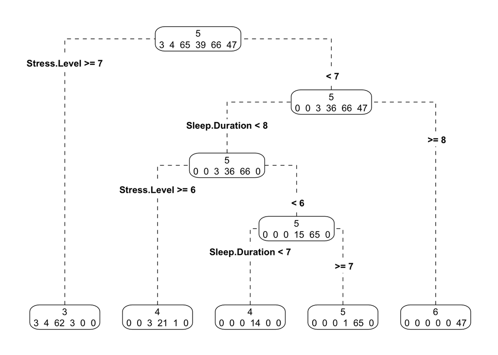

```r
options(repr.plot.width = 10, repr.plot.height = 8)
prp(tree_model, extra = 1, type = 4, branch.lty = 2, varlen = 0, yesno = 2, fallen.leaves = TRUE)
```

The decision tree model appears to perform reasonably well, especially in terms of recall and F1-Score. It demonstrates **good accuracy**, correctly classifying instances approximately 92% of the time, with **6** observations predicted in the wrong class. The **negative Cohen’s Kappa** suggests that the observed agreement is less than expected by chance. The Jaccard Index of 0.85 indicates a **good level of similarity** between the predicted and actual sets.

By looking at the decision tree, we can see that the data points are split according to **stress level** and **sleep duration**. This could imply that they play a crucial role in predicting the classes.

### Test Set Evaluation

```r
test$Quality.of.Sleep <- as.factor(test$Quality.of.Sleep)

predicted_classes_tree_test <- predict(tree_model, newdata = test, type = "class")

confusion_matrix_tree_test <- table(Actual = test$Quality.of.Sleep, Predicted = predicted_classes_tree_test)

accuracy_tree_test <- sum(diag(confusion_matrix_tree_test)) / sum(confusion_matrix_tree_test)
precision_tree_test <- diag(confusion_matrix_tree_test) / rowSums(confusion_matrix_tree_test)
recall_tree_test <- diag(confusion_matrix_tree_test) / colSums(confusion_matrix_tree_test)
f1_score_tree_test <- 2 * (precision_tree_test * recall_tree_test) / (precision_tree_test + recall_tree_test)
overall_precision_tree_test <- mean(precision_tree_test, na.rm = TRUE)
overall_recall_tree_test <- mean(recall_tree_test, na.rm = TRUE)
overall_f1_score_tree_test <- mean(f1_score_tree_test, na.rm = TRUE)
kappa_test <- kappam.fleiss(confusion_matrix_tree_test)$value

intersection <- sum(diag(confusion_matrix_tree_test))
union <- sum(confusion_matrix_tree_test) + sum(confusion_matrix_tree_test) - sum(diag(confusion_matrix_tree_test))
jaccard_index <- intersection / union

print(confusion_matrix_tree_test)
```

```
##       Predicted
## Actual  1  2  3  4  5  6
##      1  0  0  1  0  0  0
##      2  0  0  2  0  0  0
##      3  0  0 25  1  0  0
##      4  0  0  3 11  1  0
##      5  0  0  0  2 19  0
##      6  0  0  0  0  0 11
```

```r
cat("Accuracy (Decision Tree - Test Set):", accuracy_tree_test, "\n")
```

```
## Accuracy (Decision Tree - Test Set): 0.8684211
```

```r
cat("Overall Precision (Decision Tree - Test Set):", overall_precision_tree_test, "\n")
```

```
## Overall Precision (Decision Tree - Test Set): 0.5999389
```

```r
cat("Overall Recall (Decision Tree - Test Set):", overall_recall_tree_test, "\n")
```

```
## Overall Recall (Decision Tree - Test Set): 0.8855415
```

```r
cat("Overall F1-Score (Decision Tree - Test Set):", overall_f1_score_tree_test, "\n")
```

```
## Overall F1-Score (Decision Tree - Test Set): 0.8906607
```

```r
cat("Cohen's Kappa (Decision Tree - Test Set):", kappa_test, "\n")
```

```
## Cohen's Kappa (Decision Tree - Test Set): -0.08
```

```r
cat("Jaccard Index (Decision Tree - Test Set):", jaccard_index, "\n")
```

```
## Jaccard Index (Decision Tree - Test Set): 0.7674419
```

As for the test set metrics, the values are about the same as the validation set. Despite the fact that the figures are slightly lower, the performace is still **decent**. It’s just that there may be some little issue of **overfitting**. The **negative Cohen’s Kappa** values suggest that the agreement is not significantly better than chance, indicating potential areas for improvement in the model. Overall, the decision tree model appears to **generalize well to new data**, as evidenced by its consistent performance on both the validation and test sets.

## 12. LDA

### Training & Evaluation

```r
library(ggplot2)
library(MASS)
library(gridExtra)
lda_model <- lda(Quality.of.Sleep ~ Sleep.Duration + Age + Gender + Stress.Level + Sleep.Disorder + Heart.Rate, data = train)

predicted_classes_lda <- predict(lda_model, newdata = valid)$class

confusion_matrix_lda <- table(Actual = valid$Quality.of.Sleep, Predicted = predicted_classes_lda)

accuracy_lda <- sum(diag(confusion_matrix_lda)) / sum(confusion_matrix_lda)
precision_lda <- diag(confusion_matrix_lda) / rowSums(confusion_matrix_lda)
recall_lda <- diag(confusion_matrix_lda) / colSums(confusion_matrix_lda)
f1_score_lda <- 2 * (precision_lda * recall_lda) / (precision_lda + recall_lda)
overall_precision_lda <- mean(precision_lda, na.rm = TRUE)
overall_recall_lda <- mean(recall_lda, na.rm = TRUE)
overall_f1_score_lda <- mean(f1_score_lda, na.rm = TRUE)
kappa <- kappam.fleiss(confusion_matrix_lda)$value

intersection <- sum(diag(confusion_matrix_lda))
union <- sum(confusion_matrix_lda) + sum(confusion_matrix_lda) - sum(diag(confusion_matrix_lda))
jaccard_index <- intersection / union

print(confusion_matrix_lda)
```

```
##       Predicted
## Actual  1  2  3  4  5  6
##      1  1  0  0  0  0  0
##      2  0  1  0  0  0  0
##      3  0  0 14  0  0  0
##      4  0  0  1 19  3  0
##      5  0  0  0  3 19  0
##      6  0  0  0  0  0 13
```

```r
cat("Accuracy (LDA):", accuracy_lda, "\n")
```

```
## Accuracy (LDA): 0.9054054
```

```r
cat("Overall Precision (LDA):", overall_precision_lda, "\n")
```

```
## Overall Precision (LDA): 0.9482872
```

```r
cat("Overall Recall (LDA):", overall_recall_lda, "\n")
```

```
## Overall Recall (LDA): 0.9434343
```

```r
cat("Overall F1-Score (LDA):", overall_f1_score_lda, "\n")
```

```
## Overall F1-Score (LDA): 0.9455997
```

```r
cat("Cohen's Kappa (LDA):", kappa, "\n")
```

```
## Cohen's Kappa (LDA): -0.07737226
```

```r
cat("Jaccard Index (LDA):", jaccard_index, "\n")
```

```
## Jaccard Index (LDA): 0.8271605
```

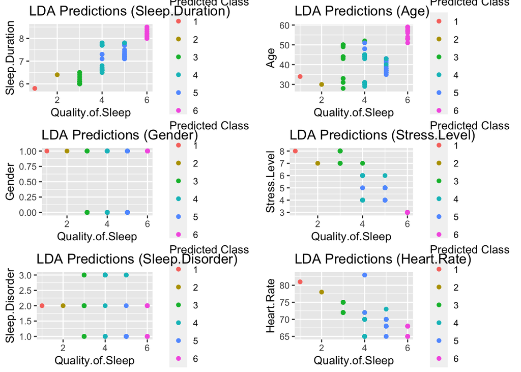

```r
valid_with_predictions_lda <- cbind(valid, Predicted = predicted_classes_lda)

plot1 <- ggplot(valid_with_predictions_lda, aes(x = Quality.of.Sleep, y = Sleep.Duration, color = as.factor(Predicted))) +
  geom_point() +
  labs(title = "LDA Predictions (Sleep.Duration)", color = "Predicted Class")

plot2 <- ggplot(valid_with_predictions_lda, aes(x = Quality.of.Sleep, y = Age, color = as.factor(Predicted))) +
  geom_point() +
  labs(title = "LDA Predictions (Age)", color = "Predicted Class")

plot3 <- ggplot(valid_with_predictions_lda, aes(x = Quality.of.Sleep, y = Gender, color = as.factor(Predicted))) +
  geom_point() +
  labs(title = "LDA Predictions (Gender)", color = "Predicted Class")

plot4 <- ggplot(valid_with_predictions_lda, aes(x = Quality.of.Sleep, y = Stress.Level, color = as.factor(Predicted))) +
  geom_point() +
  labs(title = "LDA Predictions (Stress.Level)", color = "Predicted Class")

plot5 <- ggplot(valid_with_predictions_lda, aes(x = Quality.of.Sleep, y = Sleep.Disorder, color = as.factor(Predicted))) +
  geom_point() +
  labs(title = "LDA Predictions (Sleep.Disorder)", color = "Predicted Class")

plot6 <- ggplot(valid_with_predictions_lda, aes(x = Quality.of.Sleep, y = Heart.Rate, color = as.factor(Predicted))) +
  geom_point() +
  labs(title = "LDA Predictions (Heart.Rate)", color = "Predicted Class")

grid.arrange(
  arrangeGrob(plot1, plot2, ncol = 2),
  arrangeGrob(plot3, plot4, ncol = 2),
  arrangeGrob(plot5, plot6, ncol = 2),
  nrow = 3
)
```

This LDA model is **well-performed** on the validation set, with high accuracy, precision, recall, and F1-Score. The confusion matrix illustrates that there’re **7** observations predicted in the wrong class, which is acceptable. However, the **slight negative Cohen’s Kappa** suggests that the observed agreement is **less** than expected by chance, which might be due to the imbalanced nature of the classes or other factors. The **decent value of Jaccard Index** indicates **a good degree of similarity** between predicted and actual classes.

Observing the scatter plots, higher quality of sleep can be observed with longer sleep duration, more aged, female, lower stress level, none sleep disorder or sleep apnea, and lower heart rate. Most of these results match with our common sense.

### Test Set Evaluation

```r
predicted_classes_lda_test <- predict(lda_model, newdata = test)$class

confusion_matrix_lda_test <- table(Actual = test$Quality.of.Sleep, Predicted = predicted_classes_lda_test)

accuracy_lda_test <- sum(diag(confusion_matrix_lda_test)) / sum(confusion_matrix_lda_test)
precision_lda_test <- diag(confusion_matrix_lda_test) / rowSums(confusion_matrix_lda_test)
recall_lda_test <- diag(confusion_matrix_lda_test) / colSums(confusion_matrix_lda_test)
f1_score_lda_test <- 2 * (precision_lda_test * recall_lda_test) / (precision_lda_test + recall_lda_test)
overall_precision_lda_test <- mean(precision_lda_test, na.rm = TRUE)
overall_recall_lda_test <- mean(recall_lda_test, na.rm = TRUE)
overall_f1_score_lda_test <- mean(f1_score_lda_test, na.rm = TRUE)
kappa_test <- kappam.fleiss(confusion_matrix_lda_test)$value

intersection <- sum(diag(confusion_matrix_lda_test))
union <- sum(confusion_matrix_lda_test) + sum(confusion_matrix_lda_test) - sum(diag(confusion_matrix_lda_test))
jaccard_index <- intersection / union

print(confusion_matrix_lda_test)
```

```
##       Predicted
## Actual  1  2  3  4  5  6
##      1  1  0  0  0  0  0
##      2  0  2  0  0  0  0
##      3  0  0 26  0  0  0
##      4  0  0  3 12  0  0
##      5  0  0  0  2 19  0
##      6  0  0  0  0  0 11
```

```r
cat("Accuracy (LDA):", accuracy_lda_test, "\n")
```

```
## Accuracy (LDA): 0.9342105
```

```r
cat("Overall Precision (LDA):", overall_precision_lda_test, "\n")
```

```
## Overall Precision (LDA): 0.9507937
```

```r
cat("Overall Recall (LDA):", overall_recall_lda_test, "\n")
```

```
## Overall Recall (LDA): 0.9589491
```

```r
cat("Overall F1-Score (LDA):", overall_f1_score_lda_test, "\n")
```

```
## Overall F1-Score (LDA): 0.9538401
```

```r
cat("Cohen's Kappa:", kappa_test, "\n")
```

```
## Cohen's Kappa: -0.09003984
```

```r
cat("Jaccard Index:", jaccard_index, "\n")
```

```
## Jaccard Index: 0.8765432
```

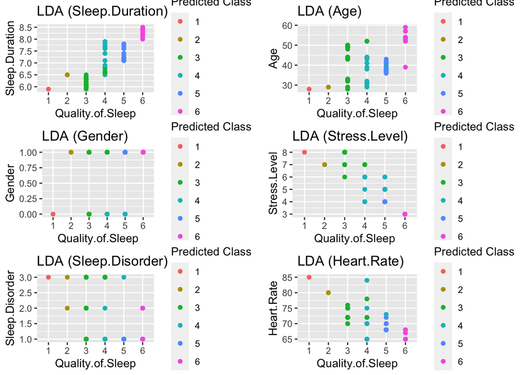

```r
test_with_predictions_lda <- cbind(test, Predicted = predicted_classes_lda_test)

plot1 <- ggplot(test_with_predictions_lda, aes(x = Quality.of.Sleep, y = Sleep.Duration, color = as.factor(Predicted))) +
  geom_point() +
  labs(title = "LDA (Sleep.Duration)", color = "Predicted Class")

plot2 <- ggplot(test_with_predictions_lda, aes(x = Quality.of.Sleep, y = Age, color = as.factor(Predicted))) +
  geom_point() +
  labs(title = "LDA (Age)", color = "Predicted Class")

plot3 <- ggplot(test_with_predictions_lda, aes(x = Quality.of.Sleep, y = Gender, color = as.factor(Predicted))) +
  geom_point() +
  labs(title = "LDA (Gender)", color = "Predicted Class")

plot4 <- ggplot(test_with_predictions_lda, aes(x = Quality.of.Sleep, y = Stress.Level, color = as.factor(Predicted))) +
  geom_point() +
  labs(title = "LDA (Stress.Level)", color = "Predicted Class")

plot5 <- ggplot(test_with_predictions_lda, aes(x = Quality.of.Sleep, y = Sleep.Disorder, color = as.factor(Predicted))) +
  geom_point() +
  labs(title = "LDA (Sleep.Disorder)", color = "Predicted Class")

plot6 <- ggplot(test_with_predictions_lda, aes(x = Quality.of.Sleep, y = Heart.Rate, color = as.factor(Predicted))) +
  geom_point() +
  labs(title = "LDA (Heart.Rate)", color = "Predicted Class")

grid.arrange(
  arrangeGrob(plot1, plot2, ncol = 2),
  arrangeGrob(plot3, plot4, ncol = 2),
  arrangeGrob(plot5, plot6, ncol = 2),
  nrow = 3
)
```

Considering the test set, we can see from the confusion matrix that there’re **5** observations that have predictions in the incorrect class, which is better than the validation set. By looking at the performance metrics, this model is **performing well**, and the figures are **slightly higher** than the metrics for validation set. Yet, the value of Cohen’s Kappa is still **slightly negative**, so the **reliability** of the model’s predictions needs to be taken into account. Overall, the model performs slightly better on the test set. This implies that the model can be deemed as good at indicating good generalization to unseen data.

The scatter plots show the same trend as the validation set.

# Conclusion

Furthermore, I realize that most models have negative cohen kappa values. This indicates the observed agreement is worse than what would be expected by chance. On top of that, even though I have split the data into 70% training set, 15% validation set, and 15% test set, there seems to be some overfitting issues across all classification models. In general, most models perform better on validation set than on test set. For models that don’t have significant differences between valid and test set, this outcome can be viewed as something normal, since the test set generally has slightly higher error metrics compared to the validation set, which is expected as models often perform slightly worse on unseen data. If I want to solve the problem of negative cohen kappa values and overfitting, perhaps next time I could perform regularization, cross-validation, feature selection, or use simpler models.

# Possible Problems To Investigate For Future Studies

1. If I adjust the proportion of the training, validation, and test sets, would the results be different ?
2. If I reduce the number of features, would the results be different ?
3. If I perform regularization, cross-validation, feature selection, or use simpler models, would the overfitting problem be solved?
4. Is there any other variable that could significantly impact the quality of sleep ?
5. How to effectively tune the parameters of the models ?